# P300 Experiment

# Results

## Participants

5 undergraduate students at Vassar College completed the experiment.

## Behavioral

Participants were asked to count the number of oddball stimuli and report the total at the end of each block. Each block contained 50 oddballs. On the whole, participants were very accurate. The largest error within an individual block across all participants was 2. The average error per block was 0.467, *SD*=0.64.

## EEG

### Segments

Across the three blocks of the experiment, there were a total of 600 blue circle events, 75 orange circle events, and 75 purple circle events. On average, subjects had 498.8 good segments for blue circles (*SD* = 79.4), 62.2 good segments for orange circles (*SD* = 11.5), and 60.8 good segments for purple circles (*SD* = 11.9). The minimum number of good segments in any condition across all subjects was 41.

### ERPs

The grand average waveforms show that the P300 is present across central and parietal electrodes (Fig. 1).

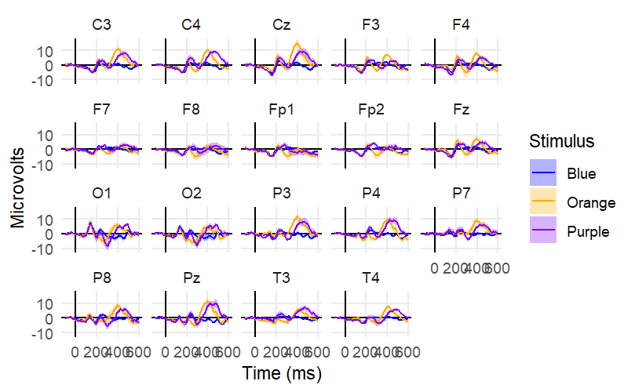

We computed difference waves by subtracting the ERP for the standard stimulus (blue circle) from the ERPs for the oddballs. The grand average difference waves for each electrode are shown in Figure 2.

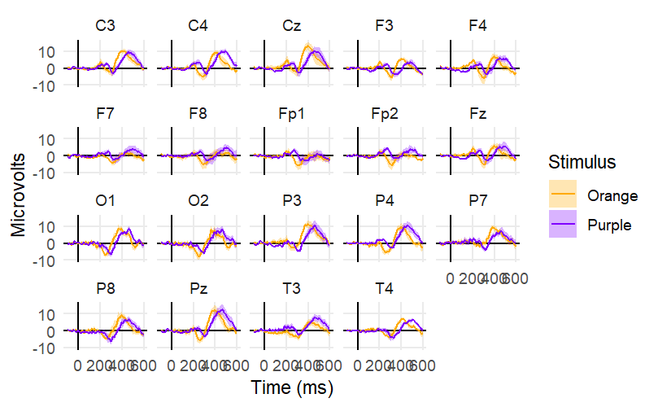

|  | Effect | DFn | DFd | F | p | p<.05 | ges |
| --- | --- | --- | --- | --- | --- | --- | --- |
| 2 | event_type | 2 | 8 | 11.12011 | 0.004898014 | * | 0.5911766 |

```
    Paired t-test

data:  m by event_type
t = 1.6583, df = 4, p-value = 0.1726
alternative hypothesis: true difference in means is not equal to 0
95 percent confidence interval:
 -1.149367  4.558547
sample estimates:
mean of the differences
                1.70459
```